# Tensornetrics - RNM

Sammie Lee

2025-03-03

```r
#Use the following to download tensornetrics from Github
#remotes::install_github("ataraxiart/tensornetrics")

library(psych)
library(psychonetrics)
library(torch)
library(tensornetrics)
library(dplyr)
library(qgraph)
```

## **Residual Network Model**

#### **Brief Explanation of Residual Network Model**

A Residual Network Model is similar to a conventional SEM model, just that we allow residuals to share partial correlations with one another by assuming a multivariate Gaussian distribution for residuals.

**In the diagram below:**

1. The white circles are our latent variables/factors
   - In the RNM, they can be assumed to be independent/have linear relations between them
2. The white squares are our observed variables (Like questions in a questionaire)
   - Arrows from factors to observed variables = Factor Loadings
3. The shaded circles are our residuals/components unexplained by latent variable
   - Arrows from residuals to observed variables = Residual Errors
   - Arrows between residuals = Partial correlations between residuals

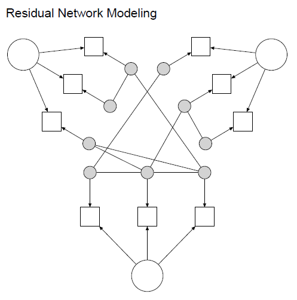

**The equation which models the covariance structure $\Sigma$ for the residual network model is as follows:**

$$\begin{equation}
\Sigma = \Lambda (1 - B)^{-1}\Psi (1 - B)^{-T} \Lambda^\top +
\Delta_{\theta} (1 - \Omega_{\theta})^{-1} \Delta_{\theta}
\end{equation}$$

#### **Explanation of Matrices**

$\Sigma$ represents the model covariance matrix.

$\Lambda$ represents the factor loadings.

$B$ represents the linear relations between the factors (If any).

$\Psi$ represents the variances and covariances of the factors.

$\Omega_\theta$ represents the partial correlations between the residuals.

$\Delta_\theta$ is a scaling matrix.

##### **The `tensor_rnm` function**

The `tensor_rnm` function in `tensornetrics` fits a Residual Network Model to data obtained (i.e. from a questionaire) but first requires the user to specify a structure for the factor loadings. ($\Lambda$ Matrix)

Non-zero partial correlations between residuals, constraints on residual errors and linear relations between factors can be specified but by default, it assumes all:

1. No partial correlations between residuals are present
2. All residual errors for observed variables are present
3. No linear relations between factors are present

`tensor_rnm` is similar to the `rnm` function in `psychonetrics` but uses a Gradient Descent method (Adam optimizer) in Torch to optimize the objective function instead of analytic gradients.

##### **Additional functionalities not found in `psychonetrics`**

`tensornetrics` also extends the functionalities of `psychonetrics` by allowing for the optimization of custom loss functions and LASSO to find non-zero partial correlations.

In this demonstration, we will just show how to use LASSO to find non-zero partial correlations between residuals that we can specify to fit models with better fit.

### **Concrete Example: Self Esteem Dataset**

Our dataset we will use for this demonstration is the `selfEsteem.txt` questionaire found in `tensornetrics` but originally from the resources on the `psychonetrics` webpage. There are 10 questions about self-esteem measured on a 4-point Likert Scale and the proposed factor structure is shown below.

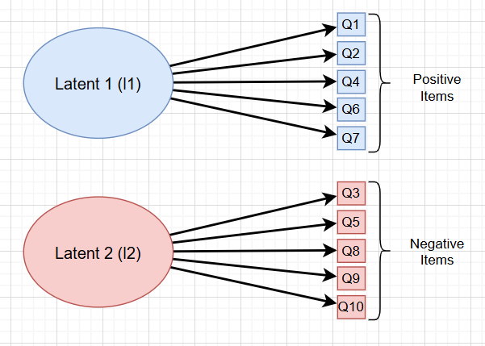

It is hypothesized that:

1. Latent Variable 1 affects responses for Q1, Q2, Q4, Q6, Q7
2. Latent Variable 2 affects responses for Q3, Q5, Q8, Q9, Q10

We will proceed to load the data and specify the structure for the factor loadings. For the purpose of this demonstration, we will split the data into `trainData` (odd values) and `testData` (even values) and train our model on `trainData` first.

```r
#RNM on self-esteem dataset

lambda <- matrix(0,10,2)
lambda[c(1,2,4,6,7),1] <- 1 # Positive items
lambda[c(3,5,8,9,10),2] <- 1 # Negative items
file_path <- system.file("selfEsteem.txt", package = "tensornetrics")
data <- read.table(file_path,header =TRUE)

trainData <- data[c(TRUE,FALSE),]
testData <- data[c(FALSE,TRUE),]
latents <- c('l1','l2')
vars <- paste0("Q",1:10)
```

### **Estimation of Model**

**To estimate a model using `tensor_rnm`, we feed the following arguments:**

1. data - dataframe of our questionaire
2. lambda - factor structure
3. vars - names of our observed variables
4. latents - names of our latent variables

**In the context of our `selfEsteem.txt` example:**

1. data - `trainData`
2. lambda - `lambda`
3. vars - `vars`
4. latents - `latents`

**To ensure uniqueness of the estimated model, there are 2 options:**

1. Setting variance of latent variables to be 1
2. Setting first factor loadings from each latent variable to be 1

**Fitting the model**

After instantiating the model using `tensor_rnm`, the `fit` method is called to fit the model to data. Note that there are no partial correlations between residuals in this fitted model.

```r
#Identify via loadings, default is via variance
#first factor loading of each latent variable is set to 1
rnm <- tensor_rnm(data=trainData,lambda,vars=vars,latents=latents,
                  lasso=FALSE,identification = 'loadings')

#Or alternatively have variance of latents set to 1
rnm <- tensor_rnm(data=trainData,lambda,vars=vars,latents=latents,
                  lasso=FALSE,identification = 'variance')


rnm$fit(verbose = TRUE)
```

[output not shown]

We can get the factor loadings:

```r
rnm$get_loadings()
```

```
##        Factor.loadings Standard.error P.value Significant
## Q1~l1            0.675          0.004       0           *
## Q2~l1            0.588          0.003       0           *
## Q4~l1            0.519          0.004       0           *
## Q6~l1            0.765          0.004       0           *
## Q7~l1            0.751          0.004       0           *
## Q3~l2            0.737          0.004       0           *
## Q5~l2            0.713          0.004       0           *
## Q8~l2            0.568          0.004       0           *
## Q9~l2            0.782          0.004       0           *
## Q10~l2           0.895          0.004       0           *
```

As mentioned, there are no partial correlations in our model if we do not specify which partial correlations should be present in our model.

```r
#By default/initially, no partial correlations are in the model/
#omega_theta matrix is just a zero matrix
#We have to perform model selection via lasso
rnm$get_partial_correlations()
```

```
## [1] "No partial correlations in model!"
```

### **LASSO to find non-zero partial correlations**

Instead of using stepwise procedures to select which partial correlations between residuals to set to non-zero inside our model, we can also apply LASSO to select the partial correlations for us.

**To do this:**

1. We instantiate an RNM model using `tensor_rnm` but set `lasso = TRUE`
2. We use the `lasso_explore` function, specifying the range of hyperparameter values `v_values` to explore and this returns an R list which contains

-The optimal hyperparameter $v$ value

-Partial Correlations to set to non-zero

```r
#Using LASSO to select for residual partial correlations to include in our network

#Instantiate an rnm module but set lasso to TRUE

rnm <- tensor_rnm(data=trainData,lambda,vars=vars,latents=latents,
                  lasso=TRUE,identification = 'loadings')

#We use lasso_explore to perform lasso
#By default algo chooses among 30 values from 0.01 to 100 on a logscale
#We try from 10000 to 100000 on a logscale here
#We set cutoff for partial correlations to be 0.0001
optimal_parameter<- lasso_explore(rnm,epsilon = 0.0001,v_values = pracma::logspace(log10(10000), log10(100000), 30))

#Here, we get a list containing value of v selected and the constraints for omega_theta
print(optimal_parameter)
```

```
## $penalty_value
## [1] 10000
##
## $free_omega_theta_params
## $free_omega_theta_params$rows
## [1]  2  7 10
##
## $free_omega_theta_params$cols
## [1] 1 6 9
##
## $free_omega_theta_params$values
## [1] 0 0 0
```

```r
#Fit the model selected by lasso
model_selected_by_lasso<- tensor_rnm(data=trainData,lambda,vars=vars,latents=latents,
                                     lasso=FALSE,identification = 'variance',
                                     omega_theta_free_lst = optimal_parameter[[2]] )

model_selected_by_lasso$fit(verbose = FALSE)

#partial correlations of new model
model_selected_by_lasso$get_partial_correlations()
```

```
##        Partial.Corr Standard.error P.value Significant
## Q1~Q2         0.309          0.005       0           *
## Q6~Q7         0.278          0.006       0           *
## Q9~Q10        0.398          0.005       0           *
```

We can further remove the insignificant partial correlations (if any) via the `prune` function in `tensornetrics`.

```r
#We can remove the insignificant partial correlations via the prune function
final_model <- tensornetrics::prune(model_selected_by_lasso)
final_model$get_partial_correlations()
```

```
##        Partial.Corr Standard.error P.value Significant
## Q1~Q2         0.309          0.005       0           *
## Q6~Q7         0.278          0.006       0           *
## Q9~Q10        0.398          0.005       0           *
```

We visualize the interactions between the residuals via the `qgraph` package:

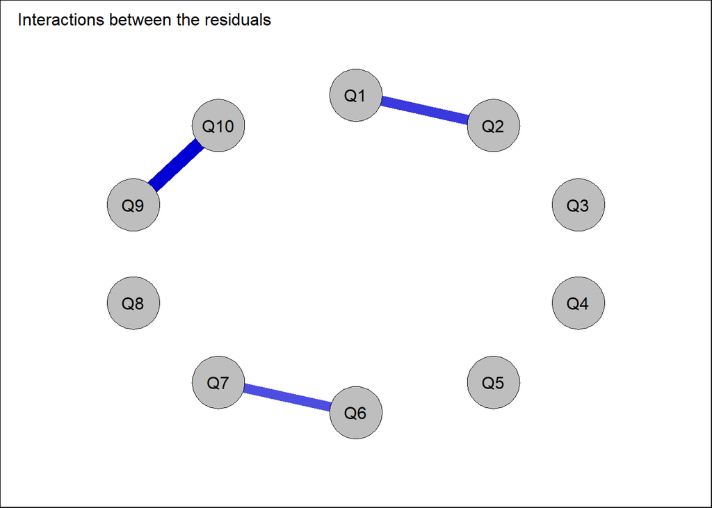

```r
qgraph(final_model$omega_theta,layout="circle",
       title="Interactions between the residuals",
       theme = "colorblind",
       labels = vars,
       vsize = 8,
       color = "gray",
       mar = rep(6,4))
box("figure")
```

We finally get some fit metrics:

```r
#Get final model criterion value and fit metrics
final_model$get_fit_metrics()
```

```
##            Metrics     Values
## 1              CFI 0.98073405
## 2              TLI 0.97203326
## 3            RMSEA 0.05757066
## 4 RMSEA.lower.0.05 0.05564503
## 5 RMSEA.upper.0.95 0.05947244
```

### **Validation on Test Data**

Lastly, we see how well the model we have found from using `trainData` fits to the `testData`. To do this we just just need to feed `tensor_rnm` the structure of our `omega_theta`(partial correlations between residuals) matrix found in `final_model`.

```r
#Test our omega_theta matrix obtained on our test data
formatted_omega_mat <-tensornetrics::format_omega_theta(final_model$omega_theta)
model_on_test <- tensor_rnm(data=testData,lambda,vars=vars,latents=latents,
                                     lasso=FALSE,identification = 'variance',
                                     omega_theta_constraint_lst = formatted_omega_mat )

model_on_test$fit(verbose = FALSE)
model_on_test$get_fit_metrics() #fits v well
```

```
##            Metrics     Values
## 1              CFI 0.97960055
## 2              TLI 0.97300071
## 3            RMSEA 0.05628286
## 4 RMSEA.lower.0.05 0.05444414
## 5 RMSEA.upper.0.95 0.05809930
```

### **Possible Issues with LASSO**

#### **1) Insufficient DF due to too many non-zero partial correlations**

-The best model returned by model is still underidentified due to too many non-zero parameters.

-The penalty parameter should be increased to force more parameters to zero.

#### **2) Heywood Cases**

-We fit the model with the non-zero partial correlations between residuals returned by lasso but when we attempt to calculate the standard errors, we get negative variances.

-A possible reason is that the model selected by lasso might still be misspecified and alternate values of the penalty value $v$ should be considered again.

```r
#Possible problems one might encounter when using LASSO

#1) Insufficient DF

#The best model returned here is still underidentified so the penalty parameter should be increased
#Theoretically, since the objective function is convex and a local minimum exists, the local #solution returned by lasso each time is unique global solution but the number of params estimated #to be non-zero might be too many, leading to model underidentification

rnm_insufficient_df <- tensor_rnm(data=trainData,lambda,vars=vars,latents=latents,
                  lasso=TRUE,identification = 'loadings')
optimal_value_of_v_insufficient <-
  lasso_explore(rnm_insufficient_df,epsilon = 0.0001,v_values = pracma::logspace(log10(0.01), log10(100), 5))
```

```
## [1] "Model will be underidentified, consider increasing penalty parameter"
```

```r
#2) Heywood Cases

#We fit the model with the constraints returned by lasso but when we attempt to calculate
#the standard errors, we get negative variances
#A possible reason is that the model selected by lasso might still be a misspecification
#and alternate values of the penalty value v should be considered again
rnm_heywood <- tensor_rnm(data=trainData,lambda,vars=vars,latents=latents,
                  lasso=TRUE,identification = 'loadings')
optimal_value_of_v_heywood <- lasso_explore(rnm_heywood ,epsilon = 0.0001,v_values = pracma::logspace(log10(1000), log10(10000), 5))
```

```
## [1] "Model will be underidentified, consider increasing penalty parameter"
```

```r
rnm_heywood  <- tensor_rnm(data=trainData,lambda,vars=vars,latents=latents,
                  lasso=FALSE,identification = 'loadings',omega_theta_free_lst = optimal_value_of_v_heywood[[2]])
rnm_heywood$fit(verbose=FALSE)
rnm_heywood$get_partial_correlations()
```

```
## [1] "Heywood Cases detected"
```

```
##        Partial.Corr Standard.error P.value Significant
## Q1~Q2         0.119            NaN     NaN        <NA>
## Q1~Q3        -0.111          0.014  0.0000           *
## Q1~Q4         0.060          0.011  0.0000           *
## Q1~Q5        -0.160            NaN     NaN        <NA>
## Q1~Q6         0.095            NaN     NaN        <NA>
## Q1~Q7         0.085          0.008  0.0000           *
## Q1~Q8        -0.163          0.005  0.0000           *
## Q1~Q9        -0.148            NaN     NaN        <NA>
## Q1~Q10       -0.209            NaN     NaN        <NA>
## Q2~Q3        -0.063          0.006  0.0000           *
## Q2~Q4         0.178          0.005  0.0000           *
## Q2~Q5        -0.124          0.006  0.0000           *
## Q2~Q6         0.087          0.005  0.0000           *
## Q2~Q7         0.048          0.004  0.0000           *
## Q2~Q9        -0.007          0.006  0.2037
## Q2~Q10       -0.056          0.007  0.0000           *
## Q3~Q4        -0.096          0.004  0.0000           *
## Q3~Q5         0.108          0.007  0.0000           *
## Q3~Q6        -0.178            NaN     NaN        <NA>
## Q3~Q7        -0.188            NaN     NaN        <NA>
## Q3~Q8         0.179            NaN     NaN        <NA>
## Q3~Q9         0.125          0.019  0.0000           *
## Q3~Q10        0.133            NaN     NaN        <NA>
## Q4~Q5        -0.049          0.005  0.0000           *
## Q4~Q6         0.049          0.004  0.0000           *
## Q4~Q7         0.054          0.004  0.0000           *
## Q4~Q9        -0.048          0.006  0.0000           *
## Q4~Q10       -0.018          0.007  0.0056           *
## Q5~Q6        -0.068          0.006  0.0000           *
## Q5~Q7        -0.116          0.005  0.0000           *
## Q5~Q8         0.023          0.010  0.0239           *
## Q5~Q9         0.074          0.004  0.0000           *
## Q5~Q10        0.079          0.006  0.0000           *
## Q6~Q7         0.359            NaN     NaN        <NA>
## Q6~Q8        -0.048            NaN     NaN        <NA>
## Q6~Q9        -0.019          0.007  0.0062           *
## Q6~Q10       -0.061          0.003  0.0000           *
## Q7~Q8        -0.032            NaN     NaN        <NA>
## Q7~Q9         0.000          0.008  0.9571
## Q7~Q10       -0.028          0.004  0.0000           *
## Q8~Q9         0.078          0.010  0.0000           *
## Q8~Q10        0.083            NaN     NaN        <NA>
## Q9~Q10        0.383            NaN     NaN        <NA>
```